# **Berlin, where best to buy property?**

## This notebook explores some of the data available on the internet to find the optimal place to buy property in Berlin. Despite house hunting being subjective in nature, the code developed here allows one to find the optimal place to buy property given the criteria one cares about. The notebook is broken down into three sections:

# 1. Data collection and processing.

# 2. Visualisation of the data.

# 3. A simple optimiser to find the best postcode to invest in.

### While the number of categories in the data is minimal (we only consider population, average house prices, and price trend over the last 8 quarters), this notebook can still give useful insights. The results were actually quite surprising.

The data visualisation aspect of this notebook was largely inspired by https://juanitorduz.github.io/germany_plots/ - so thank you to Dr. Juan Camilo Orduz for making his work publicly available.

## Installations

```python
!pip install geopandas
!apt-get -qq install python-cartopy python3-cartopy
import cartopy
!pip install geoplot
```

```
     |████████████████████████████████| 972kB 5.8MB/s
     |████████████████████████████████| 14.8MB 310kB/s
     |████████████████████████████████| 6.5MB 37.0MB/s
```

```python
import geopandas as gpd
import geoplot as gplt
import pandas as pd
import numpy as np
import matplotlib.pyplot as plt
plt.style.use('seaborn')

%matplotlib inline
```

## Data collection

In the following we collect the necessary data to generate a "map" of berlin (geocoded information). Please see https://juanitorduz.github.io/germany_plots/ for more details on where you can get this data, but I'll make it available on my repository too.

## Getting geolocation data for visualisation purposes

All the different postcodes of Germany:

```python
plz_shape_df = gpd.read_file('Data/plz-gebiete.shp', dtype={'plz': str})

plz_shape_df.head()
```

|  | plz | note | geometry |
| --- | --- | --- | --- |
| 0 | 52538 | 52538 Gangelt, Selfkant | POLYGON ((5.86632 51.05110, 5.86692 51.05124, ... |
| 1 | 47559 | 47559 Kranenburg | POLYGON ((5.94504 51.82354, 5.94580 51.82409, ... |
| 2 | 52525 | 52525 Waldfeucht, Heinsberg | POLYGON ((5.96811 51.05556, 5.96951 51.05660, ... |
| 3 | 52074 | 52074 Aachen | POLYGON ((5.97486 50.79804, 5.97495 50.79809, ... |
| 4 | 52531 | 52531 Ãbach-Palenberg | POLYGON ((6.01507 50.94788, 6.03854 50.93561, ... |

Getting data on which postcodes belong to which bundesland of Germany:

```python
plz_region_df = pd.read_csv(
    'Data/zuordnung_plz_ort.csv',
    sep=',',
    dtype={'plz': str}
)

plz_region_df.drop('osm_id', axis=1, inplace=True)

plz_region_df.tail()
```

|  | ort | plz | bundesland |
| --- | --- | --- | --- |
| 12878 | Zwiefalten | 88529 | Baden-Württemberg |
| 12879 | Zwiesel | 94227 | Bayern |
| 12880 | Zwingenberg | 69439 | Baden-Württemberg |
| 12881 | Zwingenberg | 64673 | Hessen |
| 12882 | Zwönitz | 08297 | Sachsen |

Now let's merge these together into one Berlin dataframe, that has the essential details for visualising the data:

```python
#let's write a function that allows us to merge multiple datasets and how we wish them to be merged (see pandas documents)

def merge_datasets(list_of_data_sets, on_which, list_of_hows):

  for i in range(0, len(list_of_data_sets) - 1):

    dataframe = pd.merge(left=list_of_data_sets[i], right=list_of_data_sets[i + 1], on=on_which[i], how=list_of_hows[i])

    list_of_data_sets.pop(i)
    list_of_data_sets.insert(i + 1, dataframe)

  return dataframe
```

```python
berlin_df = merge_datasets([plz_shape_df, plz_region_df], ['plz'], ['inner']).query('ort == "Berlin"')

berlin_df.drop(['note', 'bundesland'], axis=1, inplace=True)

berlin_df.head()
```

|  | plz | geometry | ort |
| --- | --- | --- | --- |
| 14033 | 14109 | POLYGON ((13.08835 52.41963, 13.09584 52.42198... | Berlin |
| 14038 | 14089 | POLYGON ((13.10929 52.45063, 13.10956 52.45108... | Berlin |
| 14084 | 13591 | POLYGON ((13.11738 52.51706, 13.11811 52.52010... | Berlin |
| 14089 | 13587 | POLYGON ((13.12796 52.58313, 13.12934 52.58593... | Berlin |
| 14114 | 13593 | POLYGON ((13.14288 52.52181, 13.14306 52.52179... | Berlin |

Let's briefly plot the geodata - looking good.

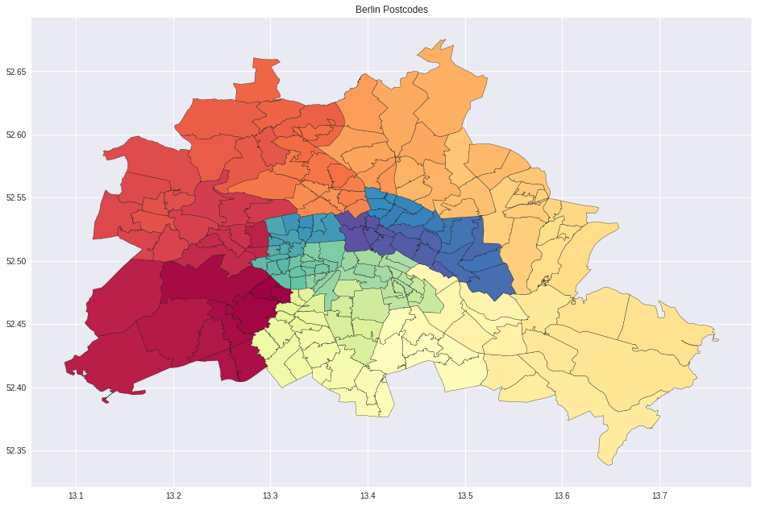

```python
fig, ax = plt.subplots(figsize=(16,11))

berlin_df.plot(
    ax=ax,
    column='plz',
    cmap= 'Spectral_r',
    edgecolor='black',
    linewidth=0.3
)

ax.set(
    title='Berlin Postcodes',
    aspect=1.3
);
```

(Let's also get data on the different Bezirke, in case we want to see the data in terms of those as well - see Dr. Juan Camilo Orduz's notebook for how he got this airbnb data)

```python
berlin_neighbourhoods_df = gpd.read_file('Data/neighbourhoods.geojson')

berlin_neighbourhoods_df = berlin_neighbourhoods_df \
    [~ berlin_neighbourhoods_df['neighbourhood_group'].isnull()]

districts_df = berlin_neighbourhoods_df.dissolve(by='neighbourhood_group')
districts_df.head()
```

| neighbourhood_group | geometry | neighbourhood |
| --- | --- | --- |
| Charlottenburg-Wilm. | POLYGON ((13.32043 52.47747, 13.32042 52.47734... | Wiesbadener Straße |
| Friedrichshain-Kreuzberg | POLYGON ((13.40736 52.48605, 13.40703 52.48598... | Frankfurter Allee Nord |
| Lichtenberg | POLYGON ((13.54173 52.49830, 13.54195 52.49828... | Neu-Hohenschönhausen Nord |
| Marzahn - Hellersdorf | POLYGON ((13.65554 52.52982, 13.65693 52.52983... | Biesdorf |
| Mitte | POLYGON ((13.37764 52.50800, 13.37762 52.50793... | Moabit West |

## Now let's collect data that might be useful for making a decision on where to buy property in Berlin.

Here we get population data per postcode address. Again see Dr. Orduz's notebook for the dataset.

```python
plz_einwohner_df = pd.read_csv(
    'Data/plz_einwohner.csv',
    sep=',',
    dtype={'plz': str, 'einwohner': int}
)

plz_einwohner_df.head()
```

|  | plz | einwohner |
| --- | --- | --- |
| 0 | 01067 | 11957 |
| 1 | 01069 | 25491 |
| 2 | 01097 | 14821 |
| 3 | 01099 | 28018 |
| 4 | 01108 | 5876 |

**Now we get to the exciting part - getting up-to-date apartment buying prices across the city**

The following code was used to collect data (current, average buying-price for flats, and average buying-price over the last three years) from the real estate website https://www.homeday.de/de/preisatlas/berlin. The data is publicly available and the following selenium-based code just automated the process of collecting and storing the data. I had to run the code locally, because google colab was being difficult with selenium.

```python
# from selenium import webdriver
# from selenium.webdriver.common.keys import Keys
# import pandas as pd
# PATH = r"C:[...]\chromedriver.exe" #note must be changed to one's own file path
# print(PATH)

# berlin_plz = ['14109', '14089', '13591', '13587', '13593', '13589', '13581', '14129', '13583', '13595', '14193', '13585', '13597', '14055', '13503', '13505', '13599', '14163', '14053', '14165', '14052', '14169', '13629', '13507', '14050', '14195', '13405', '14167', '13465', '13627', '14057', '14059', '10711', '14199', '12205', '13467', '13509', '10589', '12203', '12207', '10627', '10709', '10629', '10585', '14197', '10587', '10713', '13469', '13437', '13403', '12163', '12165', '10707', '10625', '10553', '12209', '13351', '10623', '10719', '12167', '10717', '12161', '10715', '12169', '12247', '13353', '10555', '12157', '10551', '12159', '13435', '10789', '10777', '13349', '10779', '13407', '10787', '12249', '10825', '10557', '13439', '10827', '12279', '10559', '10829', '10823', '10781', '13158', '10785', '13347', '12277', '10783', '12105', '13409', '12307', '12103', '13359', '12101', '10115', '12107', '13159', '10965', '13357', '10117', '13156', '10963', '13355', '12099', '12109', '10961', '10969', '12305', '13187', '10178', '10439', '10119', '10437', '10435', '12349', '10179', '13127', '10967', '12309', '13189', '12347', '10999', '10405', '12049', '12051', '10997', '10249', '12047', '10243', '10407', '12043', '12053', '10409', '13089', '13086', '12045', '12353', '13129', '12359', '12351', '12059', '12435', '12055', '12057', '10245', '13125', '13088', '10247', '10369', '12437', '10317', '13053', '12355', '12357', '10367', '10365', '13055', '13051', '12487', '10319', '12459', '12439', '10315', '13059', '10318', '13057', '12524', '12681', '12489', '12526', '12683', '12685', '12679', '12689', '12555', '12687', '12527', '12557', '12621', '12619', '12623', '12629', '12559', '12627', '12587', '12589']
# av_prices = []
# city_trend = []
# plz_trend = []


# for idx, i in enumerate(berlin_plz):
#     wd = webdriver.Chrome(PATH)
#     weblink = "https://www.homeday.de/de/preisatlas/berlin/{}?".format(i)
#     print(weblink)
#     print(idx + 1, "/", len(berlin_plz))
#     wd.get(weblink)
#     av_price = wd.find_elements_by_class_name("price-block__price__average")
#     price_trends = wd.find_elements_by_class_name("ct-point")

#     c_trend = []
#     for trend in price_trends[:11]:
#         c_trend += [trend.get_attribute("datavalue")]
#     city_trend.append(c_trend)

#     p_trend = []
#     for trend in price_trends[11:22]:
#         p_trend.append(trend.get_attribute("datavalue"))
#     plz_trend.append(p_trend)

#     av_prices.append(av_price[1].text[2:-5])
#     #print(av_prices)
#     wd.quit()


# dic = {'plz': berlin_plz, 'av_buy_price (€/m²)': av_prices, 'plz_buy_trend (€/m²)':plz_trend,'city_buy_trend (€/m²)':city_trend}
# buy_df = pd.DataFrame(dic)

# # saving the dataframe
# buy_df.to_csv(r'C:\Users\Admin\Desktop\Coding\buy_data.csv')
```

We now load the saved pandas csv file (which you can find on my notebook-projects folder on github)

```python
#extracting the data gathered by the code above
berlin_buy_info_df = pd.read_csv('Data/buy_data.csv', sep=',')

berlin_buy_info_df.drop(columns=berlin_buy_info_df.columns[[0]], axis=1, inplace=True)

berlin_buy_info_df.head()

#The plz buy trend contains the average prices for every quarter year since Q4 of 2017, and up until Q2 of this year.
#ie.
# 2017 Q4
# 2018 Q1, Q2, Q3, Q4
# 2019 Q1, Q2, Q3, Q4
# 2019 Q1, Q2,
```

|  | plz | av_buy_price (€/m²) | plz_buy_trend (€/m²) | city_buy_trend (€/m²) |
| --- | --- | --- | --- | --- |
| 0 | 14109 | 4.70 | ['3300', '3400', '3450', '3550', '3550', '3650... | ['4750', '5000', '5150', '5150', '5150', '5250... |
| 1 | 14089 | 3.85 | ['3300', '3400', '3450', '3550', '3550', '3650... | ['3250', '3300', '3350', '3450', '3400', '3600... |
| 2 | 13591 | 3.00 | ['3300', '3400', '3450', '3550', '3550', '3650... | ['3200', '3300', '3400', '3400', '3400', '3450... |
| 3 | 13587 | 3.00 | ['3300', '3400', '3450', '3550', '3550', '3650... | ['2950', '3000', '3050', '3150', '3150', '3000... |
| 4 | 13593 | 3.00 | ['3300', '3400', '3450', '3550', '3550', '3650... | ['3200', '3300', '3400', '3400', '3400', '3450... |

Let's merge this data with the berlin_df data and the population data

```python
#We briefly need to make sure that we are comparing the correct type
plz_einwohner_df['plz']= plz_einwohner_df['plz'].astype(str)
berlin_buy_info_df['plz']= berlin_buy_info_df['plz'].astype(str)

#And now we can merge
berlin_df = merge_datasets([berlin_df, plz_einwohner_df, berlin_buy_info_df], ['plz','plz'], ['left', 'left'])

berlin_df.head(5)
```

|  | plz | geometry | ort | einwohner | av_buy_price (€/m²) | plz_buy_trend (€/m²) | city_buy_trend (€/m²) |
| --- | --- | --- | --- | --- | --- | --- | --- |
| 0 | 14109 | POLYGON ((13.08835 52.41963, 13.09584 52.42198... | Berlin | 10049 | 4.70 | ['3300', '3400', '3450', '3550', '3550', '3650... | ['4750', '5000', '5150', '5150', '5150', '5250... |
| 1 | 14089 | POLYGON ((13.10929 52.45063, 13.10956 52.45108... | Berlin | 17734 | 3.85 | ['3300', '3400', '3450', '3550', '3550', '3650... | ['3250', '3300', '3350', '3450', '3400', '3600... |
| 2 | 13591 | POLYGON ((13.11738 52.51706, 13.11811 52.52010... | Berlin | 26762 | 3.00 | ['3300', '3400', '3450', '3550', '3550', '3650... | ['3200', '3300', '3400', '3400', '3400', '3450... |
| 3 | 13587 | POLYGON ((13.12796 52.58313, 13.12934 52.58593... | Berlin | 20108 | 3.00 | ['3300', '3400', '3450', '3550', '3550', '3650... | ['2950', '3000', '3050', '3150', '3150', '3000... |
| 4 | 13593 | POLYGON ((13.14288 52.52181, 13.14306 52.52179... | Berlin | 20238 | 3.00 | ['3300', '3400', '3450', '3550', '3550', '3650... | ['3200', '3300', '3400', '3400', '3400', '3450... |

Sweet - we have some interesting data, let's visualise it.

# Visualising the data

## Plotting Preparation

Let's prepare a couple of function and parameters to make the plotting easier

```python
plt.rcParams['figure.figsize'] = [16, 11]
from IPython.display import display
```

```python
def show_plot_for(category, show_n_largest=0, show_n_smallest=0, print_details=False, show_bezirke=False):
  fig, ax = plt.subplots()
  berlin_df.plot(
      ax=ax,
      column=category,
      categorical=False,
      legend=True,
      cmap='autumn_r',
      edgecolor='black',
      linewidth=0.3
  )


  if show_bezirke == True:
    districts_df.plot(ax=ax, edgecolor='k',linewidth = 1)


  if show_n_largest > 0:
    largest_df = berlin_df.nlargest(show_n_largest, columns=category)
    largest_df.plot(ax=ax,color='red', edgecolor='k',linewidth = 2)
    if print_details == True:
      print("--------------- Max (colour: red) -------------")
      display(largest_df)
      print("\n")


  if show_n_smallest > 0:
    smallest_df = berlin_df.nsmallest(show_n_smallest, columns=category)
    smallest_df.plot(ax=ax,color='yellow', edgecolor='k',linewidth = 2)
    if print_details == True:
      print("--------------- Min (colour: yellow) -------------")
      display(smallest_df)
      print("\n")

  ax.set(
      title='Berlin:' + category,
      aspect=1.3,
      facecolor='lightblue'
  );


def print_available_categories():
  for col_name in berlin_df.columns:
    print(col_name)
```

## Plot Data

Let's rename some of the columns and see which categories we could potentially plot

```python
#Let's rename some of the columns
berlin_df.rename(columns = {'av_buy_price (€/m²)':'Average Price', 'plz_buy_trend (€/m²)':'Plz Price Trend', 'city_buy_trend (€/m²)': 'City Price Trend'}, inplace = True)

#Show available categories
print_available_categories()
```

```
plz
geometry
ort
einwohner
Average Price
Plz Price Trend
City Price Trend
```

Let's plot the 5 most expensive postcodes (red) to buy property in and the 5 cheapest (yellow).

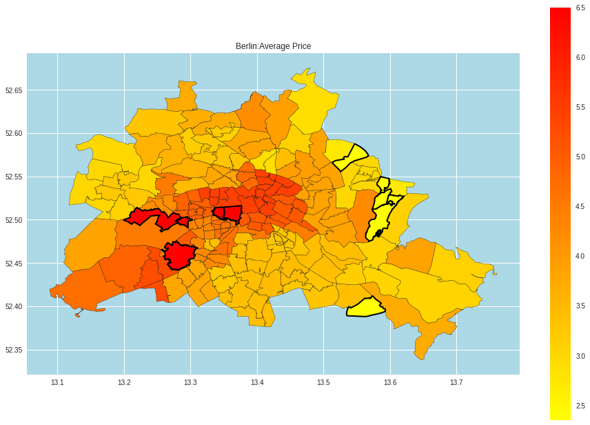

```python
 show_plot_for('Average Price', show_n_largest=5, show_n_smallest=5, show_bezirke=False)
```

Interesting! What about the most populated and least populated areas?

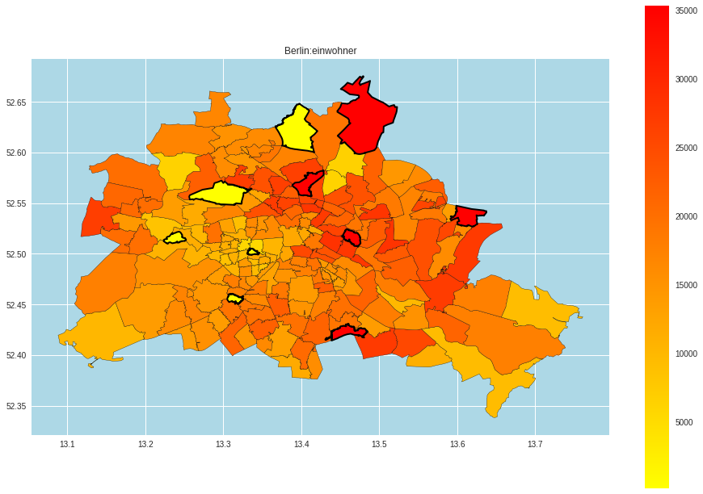

```python
 show_plot_for('einwohner', show_n_largest=5, show_n_smallest=5, show_bezirke=False)
```

I did not expect that... I thought Neukölln or Mitte would have the most populated postcodes...

## Price Trends

Let us now have a quick look at which postcodes are trending the most (and the least)

```
--------------- Max (colour: red) -------------
```

|  | plz | geometry | ort | einwohner | Average Price | Plz Price Trend | City Price Trend | Price Percentage Growth |
| --- | --- | --- | --- | --- | --- | --- | --- | --- |
| 184 | 12555 | POLYGON ((13.54563 52.47263, 13.54641 52.47316... | Berlin | 26978 | 3.05 | ['3450', '3550', '3550', '3650', '3750', '3750... | ['2450', '2550', '2650', '2650', '2800', '3000... | 30.806436 |

```
--------------- Min (colour: yellow) -------------
```

|  | plz | geometry | ort | einwohner | Average Price | Plz Price Trend | City Price Trend | Price Percentage Growth |
| --- | --- | --- | --- | --- | --- | --- | --- | --- |
| 15 | 13505 | POLYGON ((13.20820 52.59899, 13.21307 52.59909... | Berlin | 6368 | 3.6 | ['3300', '3400', '3450', '3550', '3550', '3650... | ['3350', '3400', '3450', '3550', '3500', '3250... | -1.15117 |

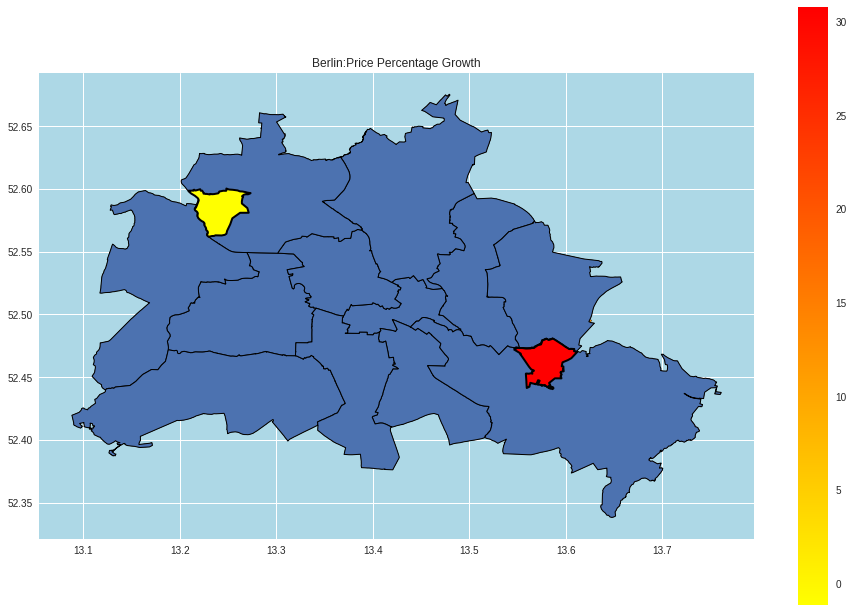

```python
#Annoyingly the price trend arrays were saved as strings, so we have to convert them to lists first
def convert_price_trend_to_array(string):

  string = string.strip('[]').replace('\'', '').split(', ')

  return [int(i) for i in string]

#Now we compute the percentage growth for over as many quarters we like (default is 4, i.e. 1 year)

def compute_percentage_growth_rate(trend_array, quarters=4):
  percentages = []

  for i in range(1, len(trend_array)):

    percentages.append(((trend_array[i] - trend_array[i - 1])/trend_array[i - 1])*100)

  return sum(percentages[:quarters])

#Let's plot the most (and least) trending postcodes over the last quarter
num_quarters = 6
berlin_df['Price Percentage Growth'] = \
 [compute_percentage_growth_rate(convert_price_trend_to_array(berlin_df['City Price Trend'][i]), quarters=num_quarters) for i in range(len(berlin_df['City Price Trend']))]

show_plot_for('Price Percentage Growth', show_n_largest=1, show_n_smallest=1, print_details=True, show_bezirke=True)
```

# Finding the Optimum Postcode to Invest In

Now we move onto finding the optimal place to invest (given our own desires). To do this I created a simple least-squares cost function that converts the descrepancies between the optimal and non-optimal ouputs of the categories to a single number. The categories that result in the minimum cost function output is considered the optimal.

```python
print_available_categories()
```

```
plz
geometry
ort
einwohner
Average Price
Plz Price Trend
City Price Trend
Price Percentage Growth
```

```python
num_quarters = 8 #change this to see percentage increase over desired number of quarters
berlin_df['Price Percentage Growth'] = \
 [compute_percentage_growth_rate(convert_price_trend_to_array(berlin_df['City Price Trend'][i]), quarters=num_quarters) for i in range(len(berlin_df['City Price Trend']))]

dict_max = {'price trend': berlin_df['Price Percentage Growth']}
dict_min = {'average price': berlin_df['Average Price']}
```

Optimisation Functions

```python
def find_min_and_max(categories_min, categories_max):
  min_opt = []
  max_opt = []

  for key, value in categories_min.items():
    min_opt.append(value.min())

  for key, value in categories_max.items():
    max_opt.append(value.max())

  return min_opt, max_opt

def cost_function(min_opt, max_opt, input_min_dict, input_max_dict):
  cost_min_dict = []
  cost_max_dict = []

  for i in range(len(min_opt)):
    cost_min_dict.append(((min_opt[i] - input_min_dict[i])/min_opt[i])**2)

  for i in range(len(max_opt)):
    cost_max_dict.append(((max_opt[i] - input_max_dict[i])/max_opt[i])**2)

  return sum(cost_min_dict) + sum(cost_max_dict)


def find_optimal_postcode(dict_min, dict_max):
  values_min = []
  for items in dict_min.values():
    values_min.append(items.tolist())

  values_max = []
  for items in dict_max.values():
    values_max.append(items.tolist())

  min_opt, max_opt = find_min_and_max(dict_min, dict_max)

  print(min_opt, max_opt)
  cost = []

  for i in range(len(values_max[0])):
    input_min_dict = []
    input_max_dict = []
    for j in range(len(values_min)):
      input_min_dict.append(values_min[j][i])

    for j in range(len(values_max)):
      input_max_dict.append(values_max[j][i])

    cost.append(cost_function(min_opt, max_opt, input_min_dict, input_max_dict))

  return cost, np.argmin(np.array(cost)), min(cost)
```

Finally... According to the two categories I have chosen, the best place to invest in is...

```
[2.35] [38.848091767738396]
```

|  | plz | geometry | ort | einwohner | Average Price | Plz Price Trend | City Price Trend | Price Percentage Growth |
| --- | --- | --- | --- | --- | --- | --- | --- | --- |
| 171 | 13059 | POLYGON ((13.49878 52.57657, 13.49891 52.57669... | Berlin | 14495 | 2.75 | ['3300', '3400', '3450', '3550', '3550', '3650... | ['2650', '2750', '2800', '2900', '2950', '3050... | 28.666963 |

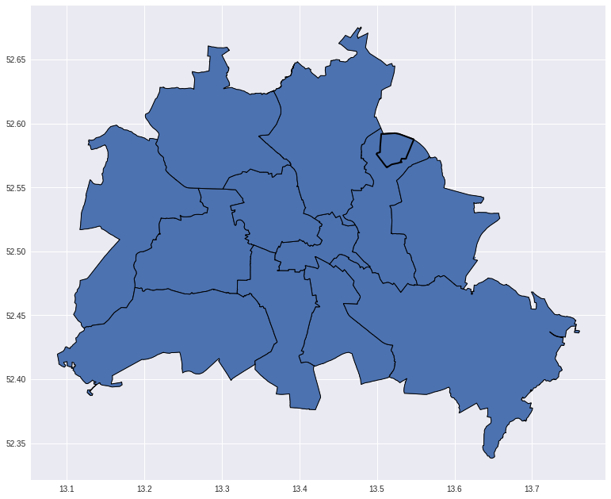

```python
cost, opt_index, min_cost = find_optimal_postcode(dict_min, dict_max)

display(berlin_df.query('index == {}'.format(opt_index)))

fig, ax = plt.subplots()

berlin_df.plot(
    ax=ax,
    categorical=False,
    legend=True,
    edgecolor='black',
    linewidth=0.3
)

districts_df.plot(ax=ax, edgecolor='k',linewidth = 1)

berlin_df.query('index == {}'.format(opt_index)).plot(ax=ax, edgecolor='black',
    linewidth=2)
```

... looks like Lichtenberg is place to invest in!

This little notebook was just a little start into an interesting investigation. A good friend of mine has just collected a vast array of other data, so we might create another notebook with a slightly different approach. I would also like to add a note on the ethics of this notebook, should you wish to use it - one should also consider the effects of gentrification, and how one's investitures into a potentially poorer area will affect the people living there.